# MidtermJSC370

Justin Won

2025-03-17

### Introduction

Crime rates vary significantly across countries and it is important to understand the factors that influence crime for economics and public policy. One key variable that is often linked to crime is income level; specifically, whether higher income levels reduce crime by increasing economic opportunities or conversely, whether income inequality increases criminal activity. Additionally, education levels have been studied as another determinant of crime since higher education is associated with better employment prospects and lower engagement in criminal activity.

This explanatory data analysis investigates the relationship between average income (GDP per capita), education levels (literacy rate), and crime rates (intentional homicides per 100,000 people) across multiple countries. I will be using data retrieved from the World Bank API and I will analyze whether countries with higher income and education levels tend to have lower crime rates.

I would like to contribute to the broader discussion on how economic and educational policies can be leveraged to reduce crime by conducting this analysis. My findings may provide insights for people seeking to implement strategies that promote safer societies through economic development and educational investments.

### Methods

```r
library(httr)
library(jsonlite)
library(dplyr)
library(ggplot2)
```

The data was retrieved using API queries in R with the httr and jsonlite packages. I found the data for this analysis from the World Bank API, which provides publicly accessible economic and social indicators for countries worldwide. I retrieved the following datasets:

Income in GDP per capita using NY.GDP.PCAP.CD measures the economic output per person in each region/country.

Crime Rate in Intentional Homicides per 100,000 using VC.IHR.PSRC.P5 represents the number of homicides per 100,000 individuals.

Education Levels in Adult Literacy Rate using SE.ADT.LITR.ZS measures the percentage of literate adults in each country.

```r
url_income <- "http://api.worldbank.org/v2/country/all/indicator/NY.GDP.PCAP.CD?format=json&date=2015"

response_income <- GET(url_income)
data_income <- content(response_income, as = "text")
json_income <- fromJSON(data_income, flatten = TRUE)

df_income <- json_income[[2]] %>%
  select(country_code = countryiso3code, year = date, income = value) %>%
  filter(!is.na(income)) %>%
  filter(country_code != "")

head(df_income)
```

Im using an API from worldbank.org. First, I got the API URL then fetched a dataset which contains regional aggregates/country code, year 2015, and income (GDP per capita) for each. Then, after fetching the data, I wanted to turn it into a dataframe, so I got the JSON format to rename the variables so that we can understand the variables more clearly. Then, I removed the N/A values for income and regional aggregates/country code to clean out the data.

```r
url_crime <- "http://api.worldbank.org/v2/country/all/indicator/VC.IHR.PSRC.P5?format=json&date=2015"

response_crime <- GET(url_crime)
data_crime <- content(response_crime, as = "text")
json_crime <- fromJSON(data_crime, flatten = TRUE)

df_crime <- json_crime[[2]] %>%
  select(country_code = countryiso3code, year = date, crime_rate = value) %>%
  filter(!is.na(crime_rate)) %>%
  filter(country_code != "")

head(df_crime)
```

Similary, I got the API URL then fetched a dataset which contains regional aggregates/country code, year 2015, and crime rate (Intentional Homicides per 100k people) for each. Then, after fetching the data, I wanted to turn it into a dataframe, so I got the JSON format to rename the variables so that we can understand the variables more clearly. Then, I removed the N/A values for crime rate and regional aggregates/country code to clean out the data.

```r
url_education <- "http://api.worldbank.org/v2/country/all/indicator/SE.ADT.LITR.ZS?format=json&date=2015"

response_education <- GET(url_education)
data_education <- content(response_education, as = "text")
json_education <- fromJSON(data_education, flatten = TRUE)

df_education <- json_education[[2]] %>%
  select(country_code = countryiso3code, year = date, literacy_rate = value) %>%
  filter(country_code != "")

head(df_education)
```

Similary, I got the API URL then fetched a dataset which contains regional aggregates/country code, year 2015, and literacy rate for each. Then, after fetching the data, I wanted to turn it into a dataframe, so I got the JSON format to rename the variables so that we can understand the variables more clearly. Then, I removed the N/A values for the regional aggregates/country code to clean out the data, but not the literacy rate since I wanted a smooth merging process.

```r
df_merged <- merge(df_income, df_crime, by = c("country_code", "year"))
df_merged <- merge(df_merged, df_education, by = c("country_code", "year"))
df_merged
```

### Method Part 2 and Preliminary Result

I used kable for the summary statistics table which includes mean, median and sd of each variables.

```r
library(dplyr)
library(kableExtra)

df_merged %>%
  summarise(
    mean_income = mean(income, na.rm = TRUE),
    median_income = median(income, na.rm = TRUE),
    sd_income = sd(income, na.rm = TRUE),
    mean_crime = mean(crime_rate, na.rm = TRUE),
    median_crime = median(crime_rate, na.rm = TRUE),
    sd_crime = sd(crime_rate, na.rm = TRUE),
    mean_literacy = mean(literacy_rate, na.rm = TRUE),
    median_literacy = median(literacy_rate, na.rm = TRUE),
    sd_literacy = sd(literacy_rate, na.rm = TRUE)
  ) %>%
  kable(caption = "Summary Statistics of Key Variables")
```

Summary Statistics of Key Variables

| mean_income | median_income | sd_income | mean_crime | median_crime | sd_crime | mean_literacy | median_literacy | sd_literacy |
| --- | --- | --- | --- | --- | --- | --- | --- | --- |
| 9242.597 | 5525.005 | 11993.84 | 7.406383 | 5.9 | 6.314062 | 78.14366 | 78.82537 | 15.46087 |

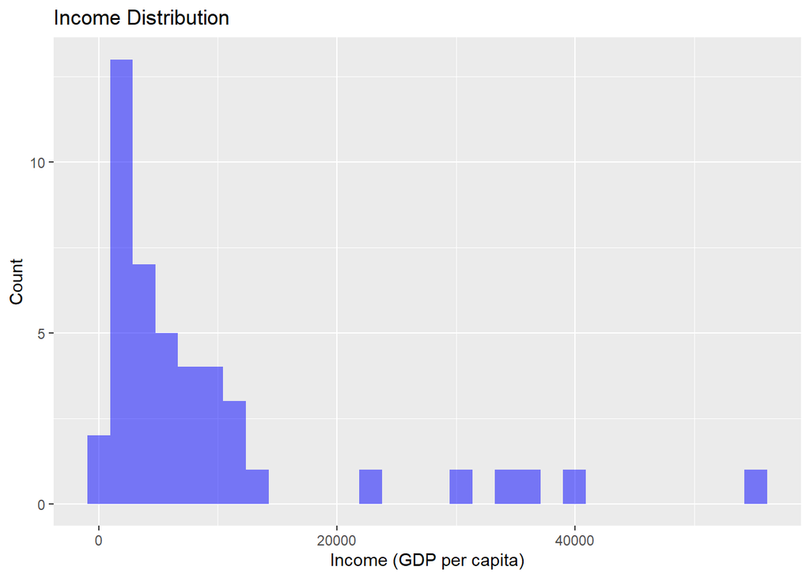

```r
# Histogram for income
ggplot(df_merged, aes(x = income)) +
  geom_histogram(bins = 30, fill = "blue", alpha = 0.5) +
  labs(title = "Income Distribution", x = "Income (GDP per capita)", y = "Count")
```

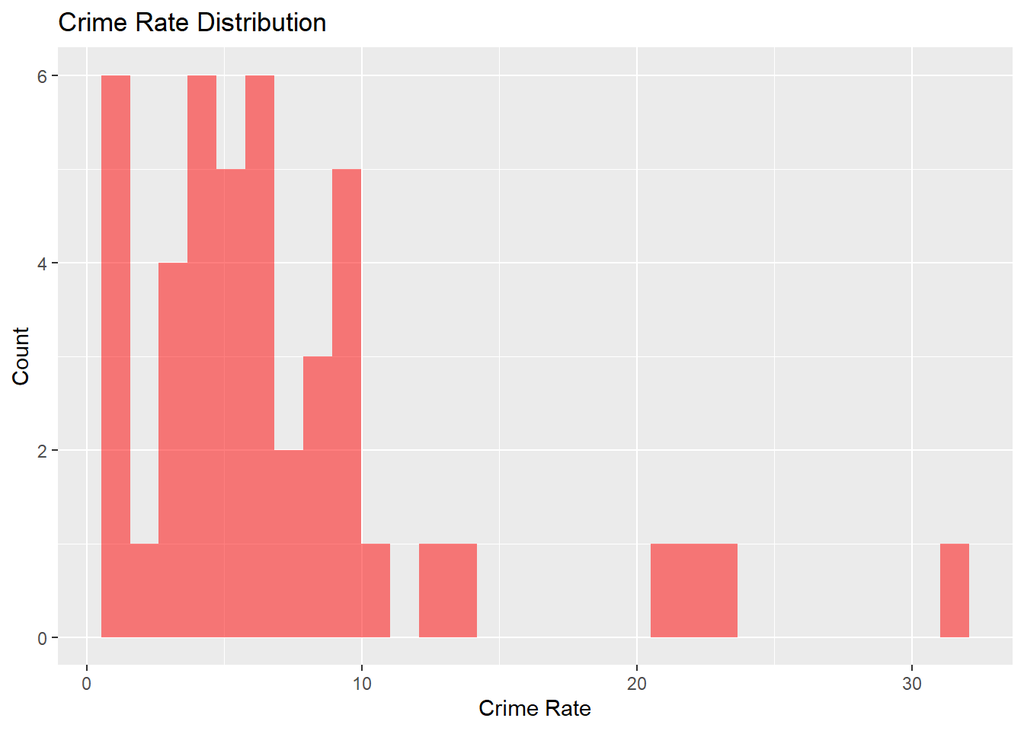

```r
# Histogram for crime rate
ggplot(df_merged, aes(x = crime_rate)) +
  geom_histogram(bins = 30, fill = "red", alpha = 0.5) +
  labs(title = "Crime Rate Distribution", x = "Crime Rate", y = "Count")
```

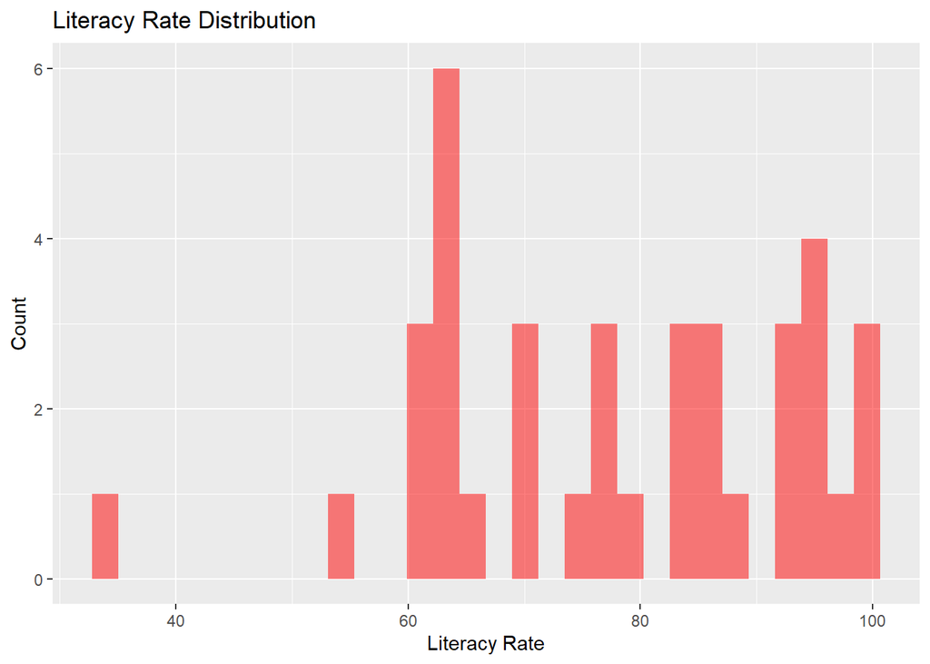

```r
# Histogram for literacy rate
ggplot(df_merged, aes(x = literacy_rate)) +
  geom_histogram(bins = 30, fill = "red", alpha = 0.5) +
  labs(title = "Literacy Rate Distribution", x = "Literacy Rate", y = "Count")
```

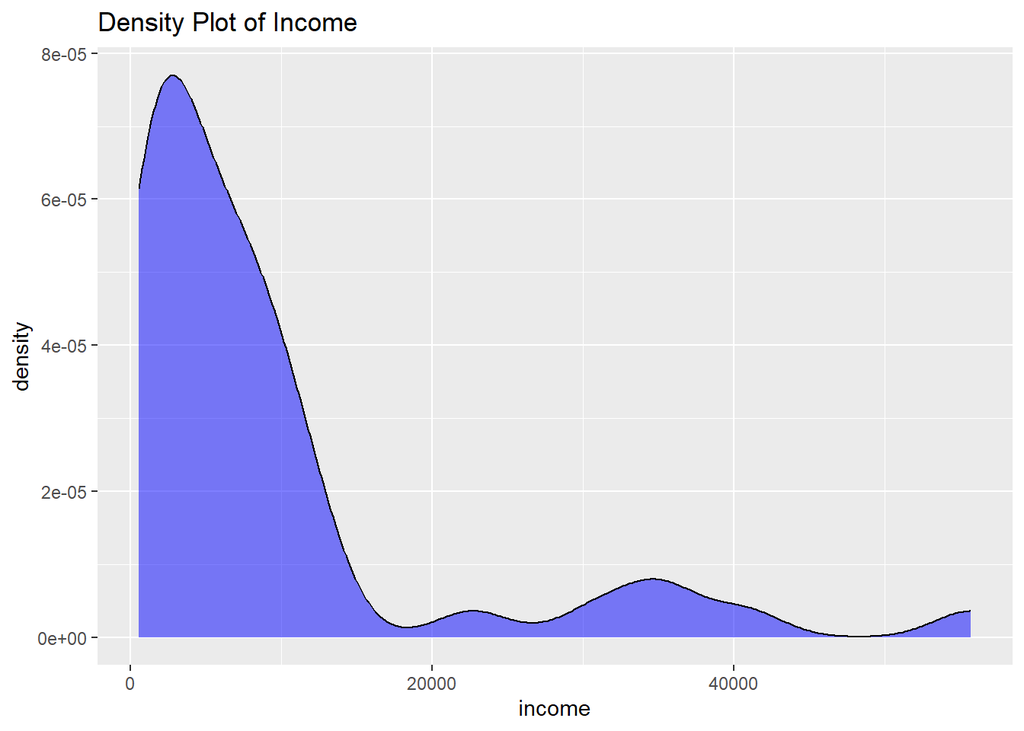

```r
# Density plot for income
ggplot(df_merged, aes(x = income)) +
  geom_density(fill = "blue", alpha = 0.5) +
  labs(title = "Density Plot of Income")
```

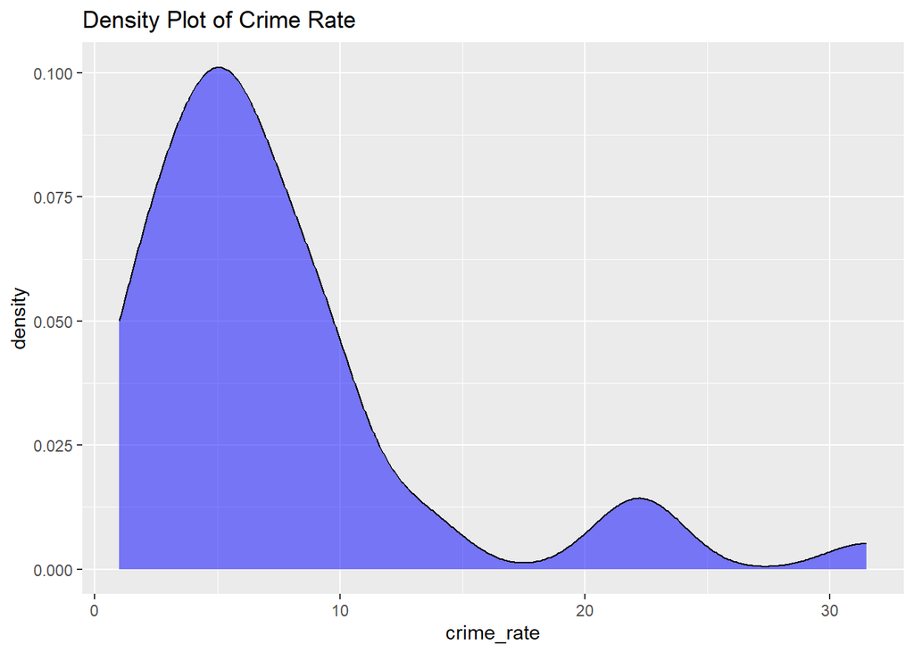

```r
# Density plot for crime rate
ggplot(df_merged, aes(x = crime_rate)) +
  geom_density(fill = "blue", alpha = 0.5) +
  labs(title = "Density Plot of Crime Rate")
```

In here, I explored the histogram to check the frequency distribution of data values. Looking at the income histogram, we can see that the data is highly right-skewed/positively skewed. A small number of countries have very high GDP per capita, pulling the distribution to the right. The majority of countries have low or moderate incomes which creates a long tail towards higher values. This means that using raw income values in this analysis might not be appropriate due to the outliers. The crime rate distribution is also right-skewed. Most countries have low crime rates, but a few have exceptionally high crime rates. This means that a small number of countries with high crime rate is dominating the dataset which could violate normality. As stated, transformations like log(crime_rate) can help normalize the distribution. However, the literacy rate appears less skewed with values clustered towards the higher end above 70-80%. Unlike income and crime rate, literacy rates seems to be normally or slightly left-skewed. Most countries have high literacy rates, with fewer having low literacy levels. Both the density plots for income and crime rate confirmed that both datasets are right skewed, so we will continue this analysis using log transformed income and crime rate.

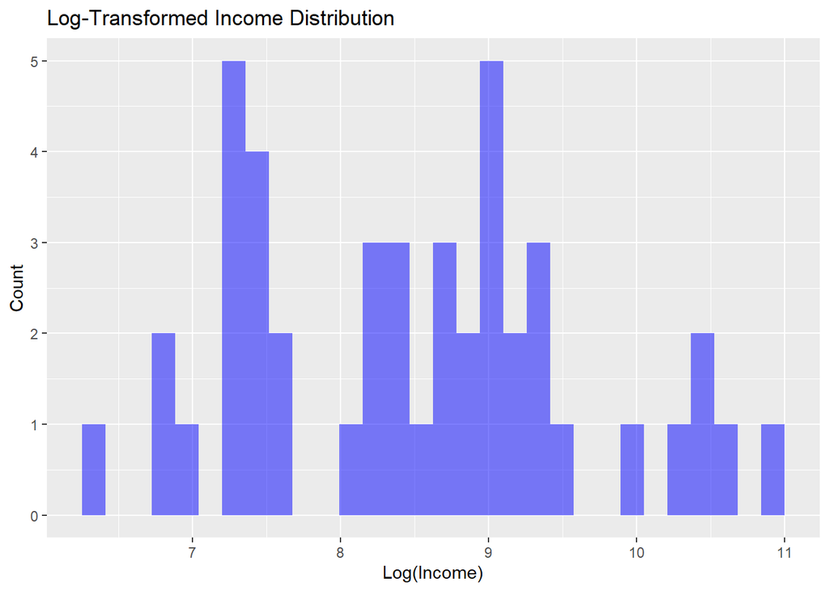

```r
ggplot(df_merged, aes(x = log(income))) +
  geom_histogram(bins = 30, fill = "blue", alpha = 0.5) +
  labs(title = "Log-Transformed Income Distribution", x = "Log(Income)", y = "Count")
```

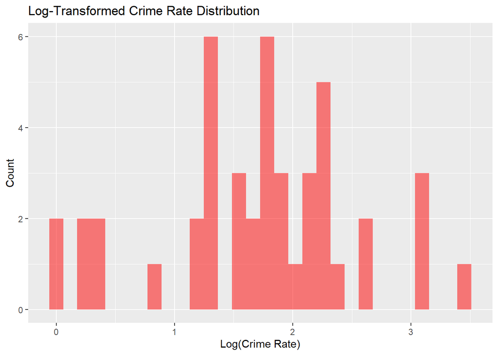

```r
ggplot(df_merged, aes(x = log(crime_rate))) +
  geom_histogram(bins = 30, fill = "red", alpha = 0.5) +
  labs(title = "Log-Transformed Crime Rate Distribution", x = "Log(Crime Rate)", y = "Count")
```

As expected, after log transforming income and crime rate, it seems more normally distributed.

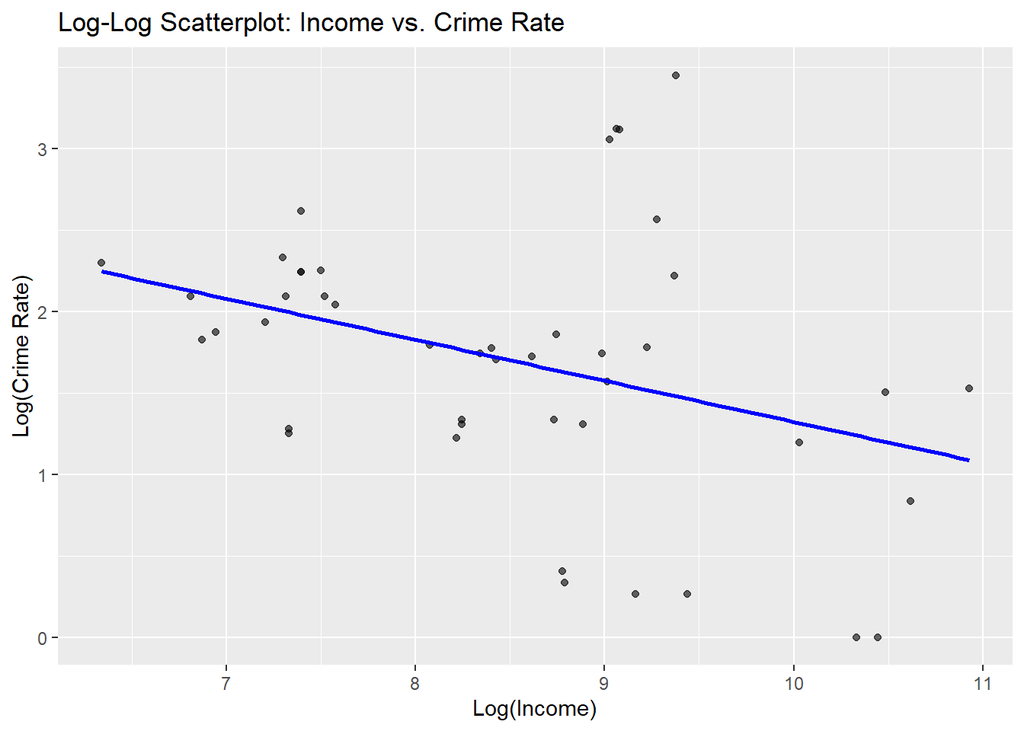

```r
ggplot(df_merged, aes(x = log(income), y = log(crime_rate))) +
  geom_point(alpha = 0.6) +
  geom_smooth(method = "lm", se = FALSE, color = "blue") +
  labs(title = "Log-Log Scatterplot: Income vs. Crime Rate",
       x = "Log(Income)", y = "Log(Crime Rate)")
```

```r
cor(log(df_merged$income), log(df_merged$crime_rate), use = "complete.obs")
```

```
## [1] -0.3522739
```

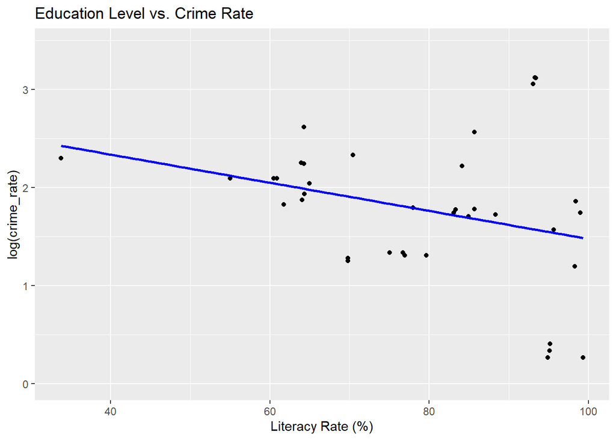

```r
ggplot(df_merged, aes(x = literacy_rate, y = log(crime_rate))) +
  geom_point() +
  geom_smooth(method = "lm", se = FALSE, color = "blue") +
  labs(title = "Education Level vs. Crime Rate",
       x = "Literacy Rate (%)",
       y = "log(crime_rate)")
```

```r
cor(df_merged$literacy_rate, log(df_merged$crime_rate), use = "complete.obs")
```

```
## [1] -0.3122335
```

For this part, we will be using the classifications from 2015 written on the worldbank website to divide the categorical variables. https://blogs.worldbank.org/en/opendata/new-country-classifications#:~:text=As%20of%201%20July%202015,GNI%20per%20capita%20of%20%2412%2C736

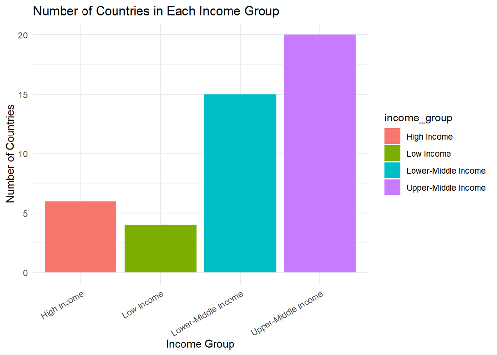

```r
df_final <- df_merged %>%
  mutate(income_group = case_when(
    income < 1045 ~ "Low Income",
    income >= 1045 & income < 4125 ~ "Lower-Middle Income",
    income >= 4125 & income < 12736 ~ "Upper-Middle Income",
    income >= 12736 ~ "High Income"
  ))

df_income_count <- df_final %>%
  count(income_group)

ggplot(df_income_count, aes(x = income_group, y = n, fill = income_group)) +
  geom_bar(stat = "identity") +
  labs(title = "Number of Countries in Each Income Group",
       x = "Income Group", y = "Number of Countries") +
  theme_minimal() +
  theme(axis.text.x = element_text(angle = 30, hjust = 1))
```

As we can see, the largest category consists of Upper-Middle Income countries which make up the highest number in this dataset. Also, a significant portion of the analyzed countries are categorized as Lower-Middle Income countries. We can also see that there are only few high and low income countries.

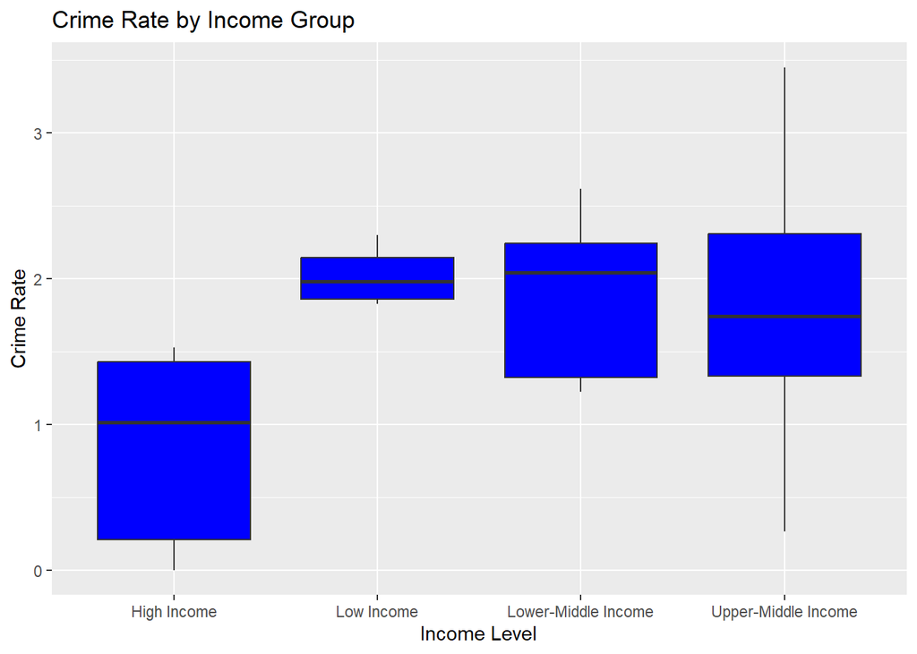

```r
ggplot(df_final, aes(x = income_group, y = log(crime_rate))) +
  geom_boxplot(fill = "blue") +
  labs(title = "Crime Rate by Income Group", x = "Income Level", y = "Crime Rate")
```

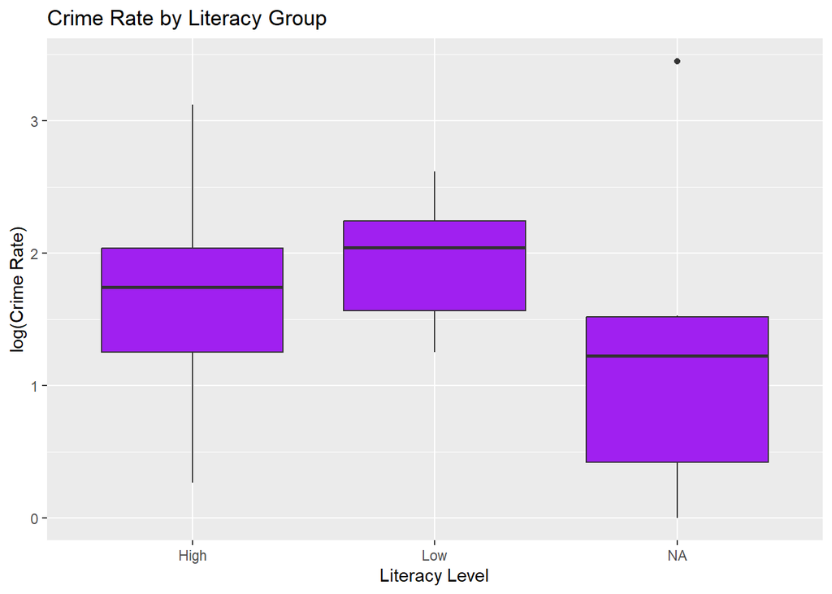

```r
df_final1 <- df_merged %>%
  mutate(literacy_group = ifelse(literacy_rate > median(literacy_rate, na.rm = TRUE), "High", "Low"))

ggplot(df_final1, aes(x = literacy_group, y = log(crime_rate))) +
  geom_boxplot(fill = "purple") +
  labs(title = "Crime Rate by Literacy Group", x = "Literacy Level", y = "log(Crime Rate)")
```

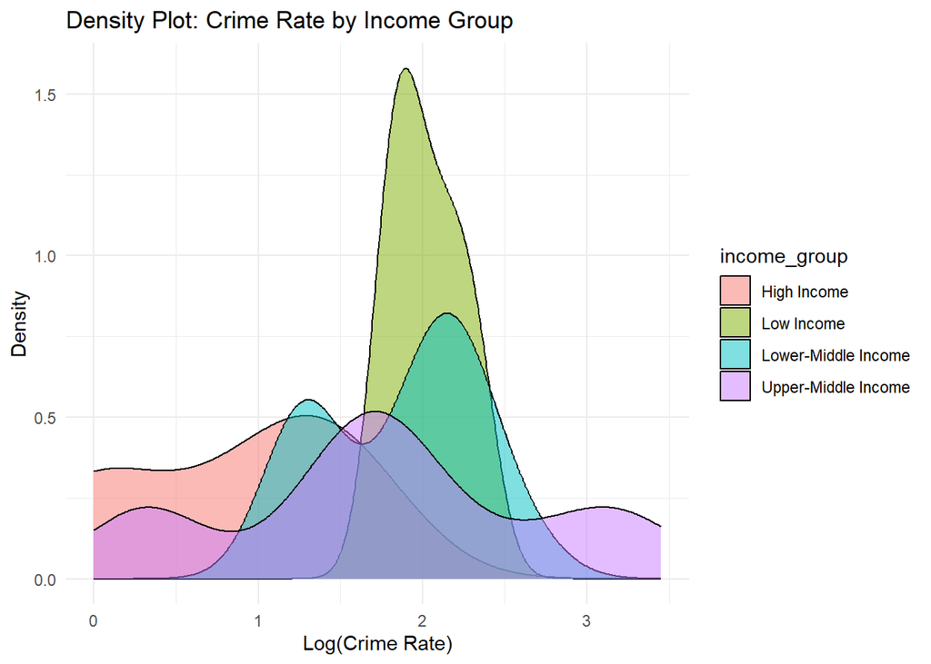

```r
ggplot(df_final, aes(x = log(crime_rate), fill = income_group)) +
  geom_density(alpha = 0.5) +
  labs(title = "Density Plot: Crime Rate by Income Group",
       x = "Log(Crime Rate)", y = "Density") +
  theme_minimal()
```

In the green region meaning Low-Income Countries, the crime rate distribution is highly concentrated around log(Crime Rate) ≈ 2.0. This shows taht most low-income countries have similar crime rates. In the light blue region meaning Lower-Middle Income, the crime rate distribution is broader with peaks around log(Crime Rate) ≈ 1.5 to 2.0. There is more variation in crime rates among lower-middle-income countries compared to low-income countries. In the purple region which represents the Upper-Middle Income, it shows a wider spread in crime rates with some countries having very low crime rates (log ≈ 0.5) and some with high crime (log > 3). The distribution is more evenly spread compared to Low-Income or Lower-Middle income countries. In the red/pink region which are High-Income countries, the crime rate distribution is more dispersed and generally lower with a peak closer to log(Crime Rate) ≈ 0.5 to 1.0. This suggests that crime rates fluctuate significantly within this group potentially due to external factors like inequality, governance, or urbanization.

```r
df_final2 <- df_merged %>%
  mutate(log_income = log(income),
         log_crime_rate = log(crime_rate))

cor <- df_final2 %>%
  select(log_income, log_crime_rate, literacy_rate) %>%
  cor(use = "complete.obs")

print(cor)
```

```
##                log_income log_crime_rate literacy_rate
## log_income      1.0000000     -0.2434619     0.9042342
## log_crime_rate -0.2434619      1.0000000    -0.3122335
## literacy_rate   0.9042342     -0.3122335     1.0000000
```

log(Income) and Literacy Rate ≈ 0.904 which means a strong positive correlation. It means that higher-income countries tend to have higher literacy rates. This makes sense because wealthier nations invest more in education, infrastructure, and public services, leading to improved literacy levels. This relationship is the strongest in the matrix implying that economic growth is strongly linked to education. log(Income) and Crime Rate ≈ 0.243 which means a weak negative correlation. This means that higher-income countries tend to have lower crime rates. However, the correlation is weak meaning that while income might influence crime, other factors such as inequality, governance, or social policies plays a significant role. This aligns with previous boxplots and density plots where Low-Income countries had consistently higher crime rates, but variation existed in Middle-Income and High-Income countries. Literacy Rate and Crime Rate ≈ -0.312 which means a Weak to moderate negative correlation. This means that countries with higher literacy rates tend to have lower crime rates. While this relationship is stronger than income-crime, it is still not very strong. As explained, Other factors may be involved in this variaton.

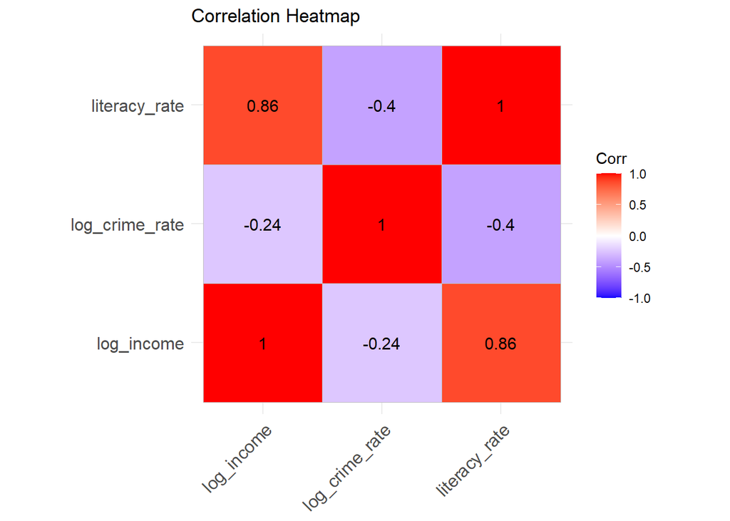

```r
library(ggcorrplot)
cor_matrix <- df_final2 %>%
  select(log_income, log_crime_rate, literacy_rate) %>%
  cor(method = "spearman", use = "complete.obs")

ggcorrplot(cor_matrix, lab = TRUE, title = "Correlation Heatmap")
```

We use the Spearman method and a heatmap for this. Income and Literacy Rate is 0.86 which shows a strong positive correlation. This suggests that higher-income countries tend to have higher literacy rates. This relationship is expected, as wealthier countries typically invest more in education, leading to higher literacy levels. Income and Crime Rate is -0.24 which shows a weak negative correlation. This suggests that higher-income countries tend to have lower crime rates, but the relationship is not strong. This implies that income alone does not fully explain crime rates, and other factors plays a role. Literacy Rate and Crime Rate is -0.40 which is a moderate negative correlation. This shows that higher literacy rates tend to have lower crime rates. While literacy appears to have a stronger negative correlation with crime than income, the relationship is still not definitive, meaning other factors might also influence crime rates as explained.

### Summary

The goal of this exploratory data analysis was to investigate the relationship between income, education levels, and crime rates across different regions/countries. The analysis used World Bank API data to retrieve GDP per capita, literacy rate, and intentional homicide rates.

Some key findings were: Income and Literacy Rate: A strong positive correlation of 0.86 was found between income and literacy rate, confirming that wealthier countries tend to have higher literacy levels. Income and Crime Rate: A weak negative correlation of -0.24 suggested that higher-income countries generally have lower crime rates, but the relationship is not strong. Literacy and Crime Rate: A moderate negative correlation -0.40 showed that higher literacy rates are associated with lower crime rates, but other factors may also influence crime levels. Distribution of Crime Rates: Low-income countries showed higher crime rates with less variation. Middle-income countries had the highest variation in crime which meant that income alone does not fully explain crime trends. High-income countries exhibited generally lower crime rates but still showed some variation. Boxplots & Density Plots: These visualizations confirmed that crime rates tend to be higher in lower-income and lower-literacy countries, but exceptions exist.

For the final project, I plan to build on these findings by———————————–

Statistical testing: I would like to dive deeper on Spearman’s correlation to verify relationships while accounting for non-linear trends. I would also like to do Shapiro-Wilk test (learned from STA355) to test for normality, look at residual plots and do weighted regression if needed.

Regression Analysis: I would like to conduct multiple regression to determine whether income or literacy rate is a stronger predictor of crime rates. I could also introduce the Gini Index (income inequality) (learned from STA355) to examine its impact on crime.

Additional Visualizations: With a bigger dataset, I want to create a geospatial crime maps to visualize patterns across regions and compare crime rates across regions.

I could also dive deeper on interpretations and discuss potential socioeconomic policies that could reduce crime rates based on findings.